# prefviz

Visualize preferential data using ternary plots in 2D and higher dimensions

## Imagine you are a club president, and you want to figure what drinks to order for the next major events…

So you make a list of drinks, and go out to ask every member to rank their preference from most to least preferred.

1. Coke
2. Orange juice
3. Coffee

After everyone has made their choice, your data looks like this:

```
# A tibble: 15 × 3
   name  drink_type    rank
   <fct> <fct>        <int>
 1 Alice coke             3
 2 Ben   coke             2
 3 Carla coke             2
 4 David coke             1
 5 Ella  coke             2
 6 Alice orange juice     1
 7 Ben   orange juice     1
 8 Carla orange juice     3
 9 David orange juice     2
10 Ella  orange juice     1
11 Alice coffee           2
12 Ben   coffee           3
13 Carla coffee           1
14 David coffee           3
15 Ella  coffee           3
```

## You decided to look into people’s first choice

```r
composition_tbl <- tibble(
  coke = 0.30,
  `orange juice` = 0.20,
  coffee = 0.50
)

kable(composition_tbl)
```

[output not shown]

Which can be visualized easily with a bar chart or a stacked bar chart

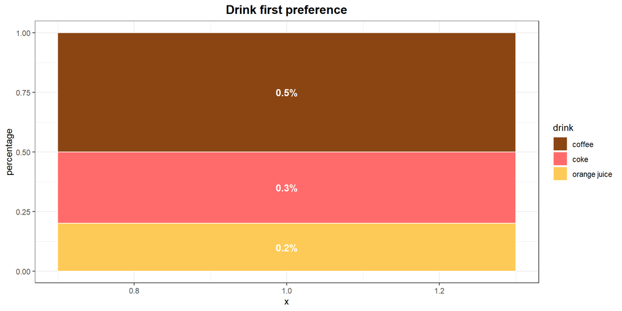

```r
composition_long <- composition_tbl %>%
  pivot_longer(everything(), names_to = "drink", values_to = "percentage")

# Create stacked bar chart
ggplot(composition_long, aes(x = 1, y = percentage, fill = drink)) +
  geom_col(width = 0.6, color = "white", linewidth = 0.5) +
  geom_text(aes(label = paste0(percentage, "%")),
            position = position_stack(vjust = 0.5),
            color = "white", fontface = "bold", size = 4) +
  scale_fill_manual(values = c("coke" = "#FF6B6B",
                               "orange juice" = "#FECA57",
                               "coffee" = "#8B4513")) +
  labs(title = "Drink first preference")  +
  theme_bw() +
  theme(legend.position = "right",
        plot.title = element_text(hjust = 0.5, size = 14, face = "bold"),
        plot.subtitle = element_text(hjust = 0.5, size = 12))
```

## What if you run the same poll in all 4 Monash campuses?

Here is the data you collected:

```r
composition_tbl <- tibble(
  campus = c("Clayton", "Caulfield", "Peninsula", "Parkville"),
  coke = c(0.70, 0.20, 0.10, 0.05),
  `orange juice` = c(0.10, 0.60, 0.15, 0.25),
  coffee = c(0.20, 0.20, 0.75, 0.70)
)

kable(composition_tbl)
```

| campus | coke | orange juice | coffee |
| --- | --- | --- | --- |
| Clayton | 0.70 | 0.10 | 0.20 |
| Caulfield | 0.20 | 0.60 | 0.20 |
| Peninsula | 0.10 | 0.15 | 0.75 |
| Parkville | 0.05 | 0.25 | 0.70 |

Visualizing the data is a bit more challenging, but it’s still possible to see the differences between the campuses.

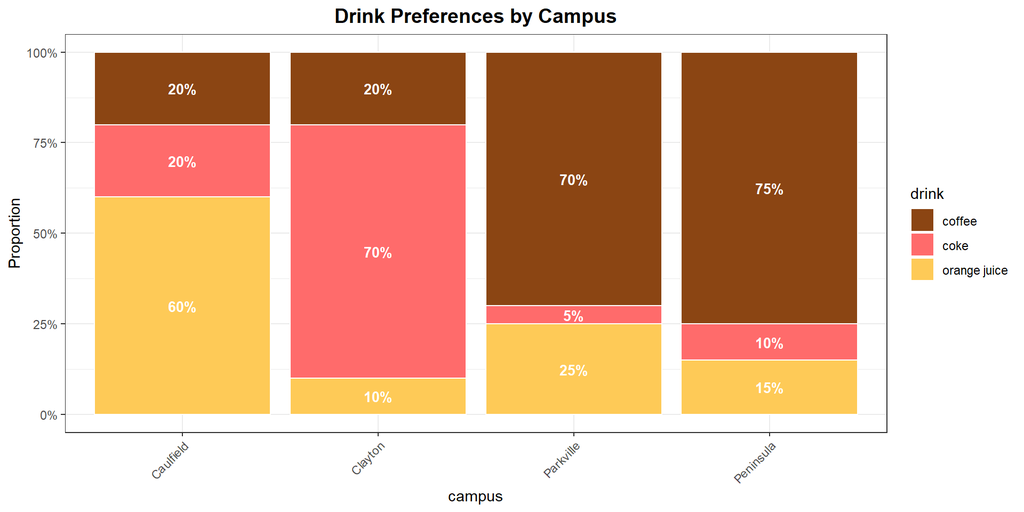

```r
composition_long <- composition_tbl %>%
  pivot_longer(-campus, names_to = "drink", values_to = "pct")

ggplot(composition_long, aes(x = campus, y = pct, fill = drink)) +
  geom_col(color = "white", linewidth = 0.5) +
  geom_text(aes(label = scales::percent(pct, accuracy = 1)),
            position = position_stack(vjust = 0.5),
            color = "white", fontface = "bold", size = 3.5) +
  scale_fill_manual(values = c("coke" = "#FF6B6B",
                               "orange juice" = "#FECA57",
                               "coffee" = "#8B4513")) +
  labs(y = "Proportion", title = "Drink Preferences by Campus") +
  theme_bw() +
  theme(legend.position = "right",
        plot.title = element_text(hjust = 0.5, size = 14, face = "bold"),
        axis.text.x = element_text(angle = 45, hjust = 1)) +
  scale_y_continuous(labels = scales::percent)
```

## But what if you run this poll across all university campuses in Australia?

I don’t know how many campuses there are in Australia, but assume 150 campuses 😬😬😬

```r
set.seed(42)
n_campuses <- 150

# Generate 150 campus compositions (same diverse patterns as 4-campus example)
composition_tbl <- tibble(
  campus = paste0("Campus_", 1:n_campuses),
  coke = runif(n_campuses, 0.05, 0.80),
  `orange juice` = runif(n_campuses, 0.05, 0.80),
  coffee = 1 - coke - `orange juice`
) %>%
  mutate(across(coke:`orange juice`, ~ pmax(pmin(., 0.90), 0.05))) %>%
  mutate(coffee = 1 - coke - `orange juice`) |>
  filter(coffee > 0, coke > 0, `orange juice` > 0)

# Same 4-campus style plot, now for 150 campuses
composition_long <- composition_tbl %>%
  pivot_longer(-campus, names_to = "drink", values_to = "pct")

ggplot(composition_long, aes(x = campus, y = pct, fill = drink)) +
  geom_col(color = "white", linewidth = 0.5) +
  geom_text(aes(label = scales::percent(pct, accuracy = 1)),
            position = position_stack(vjust = 0.5),
            color = "white", fontface = "bold", size = 2) +
  scale_fill_manual(values = c("coke" = "#FF6B6B",
                               "orange juice" = "#FECA57",
                               "coffee" = "#8B4513")) +
  labs(y = "Proportion", title = "Drink Preferences: 150 Campuses") +
  theme(legend.position = "right",
        plot.title = element_text(hjust = 0.5, size = 14, face = "bold"),
        axis.text.x = element_text(angle = 90, hjust = 1, size = 3),
        strip.text = element_text(size = 6))
```

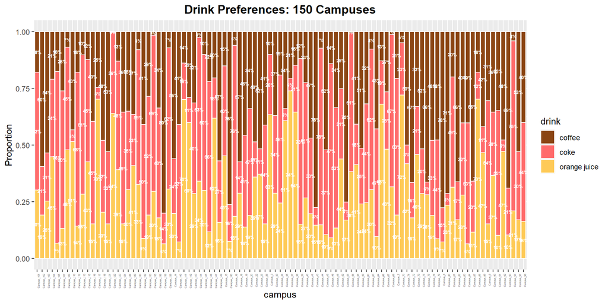

## Introduce: Ternary plot 🎉🎉🎉

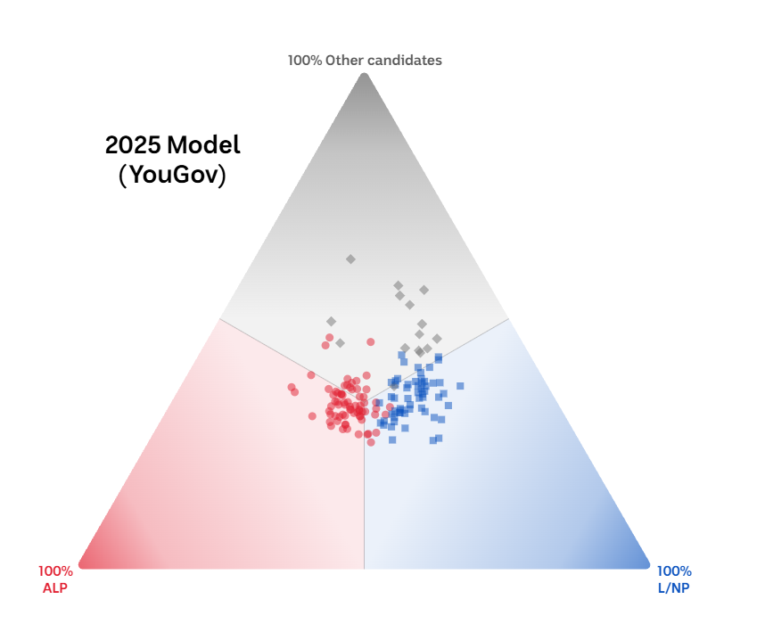

*ABC News shows interesting plot on 2025 House of Rep’s distribution of first preference*

**How to read this plot?**

- The edges are the axes, running from 0 to 1
- Each point represents 1 observation (or stacked bar), and is made up of 3 parts: %ALP, %LNP, and %Other
- If the point sits at one of the vertices, it means 100% of the composition is in that party.
- If the point sits in the center, it means equal compositions of all party (33% each)

## We make it interactive!

Hover to see electorate names and exact vote percentages.

[interactive chart not shown]

## We make it interactive!

**Explore with map of electorate**

Link the ternary plot with a map of electorates. Selecting a point in the ternary plot highlights the corresponding electorate on the map, and vice versa.

[interactive chart not shown]

## We bring it to high dimensions!

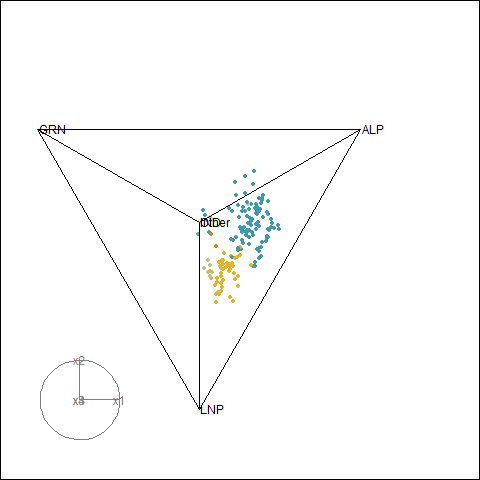

And interactive!

[interactive chart not shown]

# `prefviz`

- For preferential data
- For **any dimensions**
- Make it interactive and linkable